# Project: Identify Customer Segments

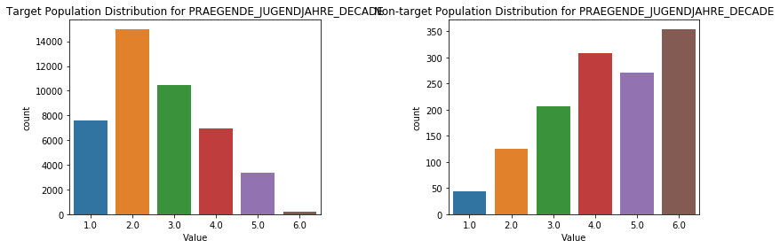

```python
# Compare plots for decade
compare_plots('PRAEGENDE_JUGENDJAHRE_DECADE', target, nontarget)
```

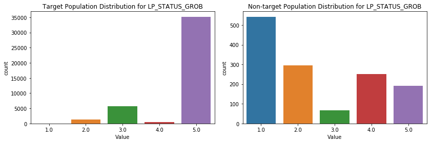

```python
# Compare plots for social status, rough scale
compare_plots('LP_STATUS_GROB', target, nontarget)
```

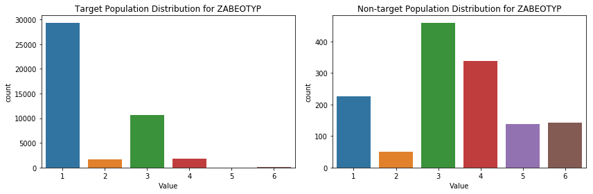

```python
# Compare plots for energy consumption typology
compare_plots('ZABEOTYP', target, nontarget)
```

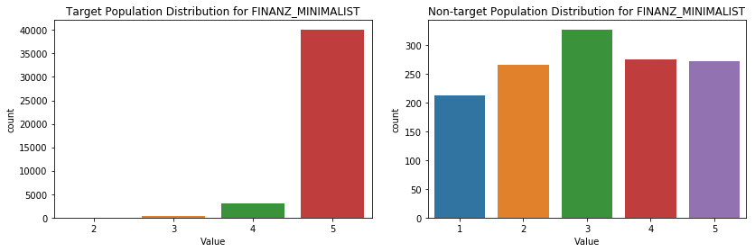

```python
# Compare plots for low financial interest
compare_plots('FINANZ_MINIMALIST', target, nontarget)
```

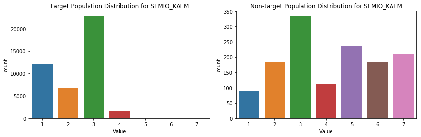

```python
# Compare plots for combative attitude
compare_plots('SEMIO_KAEM', target, nontarget)
```

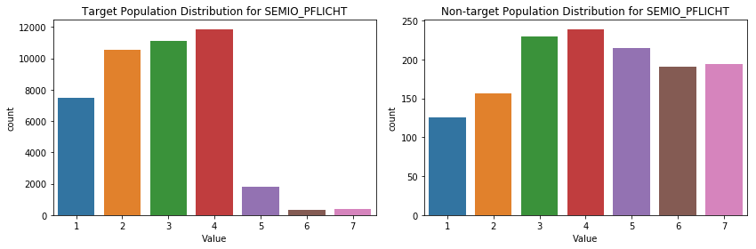

```python
# Compare plots for dutiful
compare_plots('SEMIO_PFLICHT', target, nontarget)
```

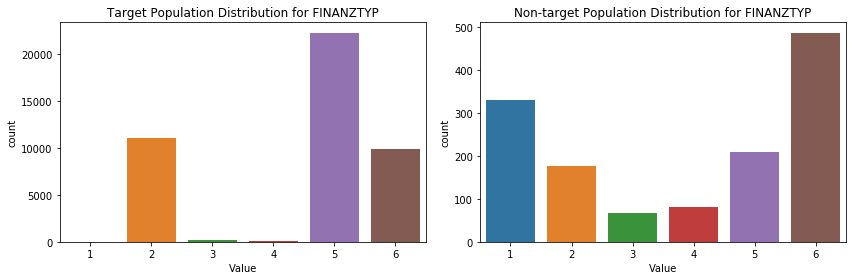

```python
# Compare plots for most descriptive financial type for individual
compare_plots('FINANZTYP', target, nontarget)
```

```python
def plot_scaled_comparison(df_sample, kmeans, cluster):
    '''
    Applies the inverse transform through the PCA transform to get the magnitudes of the scaled coefficients and
    plots the results.
    INPUT:
        df_sample - dataset (DataFrame)
        kmeans - KMeans object
        cluster - number of cluster (int)
    OUTPUT:
        None
    '''
    X = pd.DataFrame.from_dict(dict(zip(df_sample.columns, pca.inverse_transform(kmeans.cluster_centers_[cluster]))), orient='index').rename(columns={0: 'feature_values'}).sort_values('feature_values', ascending=False)
    X['feature_values_abs'] = abs(X['feature_values'])
    pd.concat((X['feature_values'][:10], X['feature_values'][-10:]), axis=0).plot(kind='barh');
```

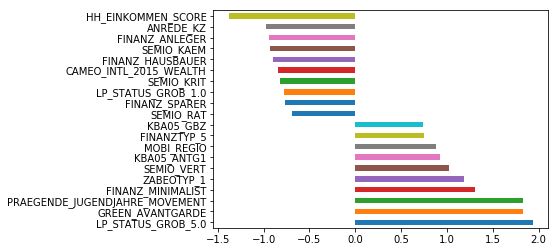

```python
# Note that since StandardScaler was used, strongly negative values suggest lower values on the original scale
# and positive values suggest higher values on the original scale
plot_scaled_comparison(customers_nonan, kmeans, 2)
```

### Discussion 3.3: Compare Customer Data to Demographics Data

The highest clusters in the "Cluster Ratios of Customers to General" graph are 2 and 12. Cluster 2 was used to find types of people who are overrepresented in the customer data compared to the general population.

The highest cluster in the "Cluster Ratios of General to Customers" graph is 13. This cluster was used to find types of people who are underrepresented in the customer data compared to the general population.

Since there appears to be participation bias when comparing the subset containing high missing values with the subset containing low missing values, only rows with less than or equal to 10 missing values were kept in the azdias and customer datasets for cluster analysis.

Based on the PCA interpretations from STEP 2.3, the following features were explored comparing clusters 2 and 13.

ANREDE_KZ - Gender

- 1: male
- 2: female

Males are overwhelmingly popular with the mail-order company.

PRAEGENDE_JUGENDJAHRE_DECADE

- 1: 40s
- 2: 40s
- 3: 50s
- 4: 50s
- 5: 60s
- 6: 60s
- 7: 60s
- 8: 70s
- 9: 70s
- 10: 80s
- 11: 80s
- 12: 80s
- 13: 80s
- 14: 90s
- 15: 90s

The mail-order company is more popular with older people.

Conversely, those born in the 90s are considerably underrepresented. This seems to indicate that this age group has low interest in the company.

LP_STATUS_GROB - Social status, rough scale

- 1: low-income earners (maps to 1-2 in fine scale)
- 2: average earners (maps to 3-5 in fine scale)
- 3: independents (maps to 6-7 in fine scale)
- 4: houseowners (maps to 8-9 in fine scale)
- 5: top earners (maps to 10 in fine scale)

Top earners are popular with the mail-order company.

ZABEOTYP - Energy consumption typology

- 1: green
- 2: smart
- 3: fair supplied
- 4: price driven
- 5: seeking orientation
- 6: indifferent

The mail-order company is popular with those who identify as green under energy consumption type.

FINANZ_MINIMALIST - low financial interest

- 1: very high
- 2: high
- 3: average
- 4: low
- 5: very low

Those who chose very low (5) under FINANZ_MINIMALIST are overrepresented in the customer base. This implies that the customer base is least likely to exhibit low financial interest.

FINANZTYP - most descriptive financial type for individual

- 1: low financial interest (MINIMALIST)
- 2: money-saver (SPARER)
- 3: home ownership (HAUSBAUER)
- 4: be prepared (VORSORGER)
- 5: investor (ANLEGER)
- 6: inconspicuous (UNAUFFAELLIGER)

Corresponding with FINANZ_MINIMALIST, customers are least likely to be of the financial type, MINIMALIST.

SEMIO-KAEM - combative attitude, SEMIO-PLICHT - dutiful

- 1: highest affinity
- 2: very high affinity
- 3: high affinity
- 4: average affinity
- 5: low affinity
- 6: very low affinity
- 7: lowest affinity

Those with higher affinity to the personality types SEMIO-KAEM and SEMIO-PLICHT are more popular with the mail-order company.

The last plot supports most of these observations.

In summary, the mail-order company should target environmentally conscious, high-income males born between 1940 to 1970 with combative and dutiful personality types.

> Congratulations on making it this far in the project! Before you finish, make sure to check through the entire notebook from top to bottom to make sure that your analysis follows a logical flow and all of your findings are documented in **Discussion** cells. Once you've checked over all of your work, you should export the notebook as an HTML document to submit for evaluation. You can do this from the menu, navigating to **File -> Download as -> HTML (.html)**. You will submit both that document and this notebook for your project submission.

```python
# Get versions of software used
!pip list
```

[output not shown]

[output cut: 150 more lines]

[output not shown]

```python
# List python version
from platform import python_version
print(python_version())
```

```
3.6.3
```

```python
# Convert notebook to html
!!jupyter nbconvert *.ipynb
```

```
['[NbConvertApp] Converting notebook Identify_Customer_Segments.ipynb to html',
 '[NbConvertApp] Writing 1786539 bytes to Identify_Customer_Segments.html']
```